# sPLS-DA for 10x Single-cell RNA-Seq

# Check the final model

As we have selected the parameters which gives a good level of satisfaction in terms of prediction, we want to check out what we selected.

## Model builing

Build the desired model and plot the components. Discuss about the interest of the components to discriminate the classes.

```r
ncomp <- 3
modele <- splsda(X_4_pop,y_4_pop,ncomp = ncomp,keepX = c(7,5,6))
```

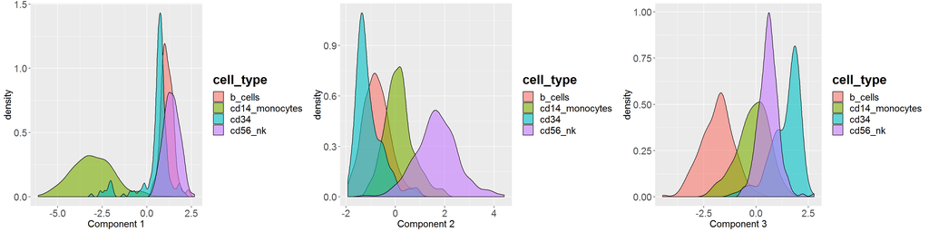

```r
plots <- list()
for(i in 1:ncomp){
  dat <- data.frame(VariateX = modele$variates$X[,i], cell_type = y_4_pop)
  a <- ggplot(dat, aes(x = VariateX, fill = cell_type)) +
    geom_density(alpha = 0.6)+theme(
      legend.title = element_text(size = 20, face = "bold"),
      legend.text = element_text(size = 15),
        axis.title = element_text(size=15),
        axis.text = element_text(size=15))+
    xlab(paste("Component",i))
  plots[[i]] <- a
}
do.call(gridExtra::grid.arrange,  c(grobs=plots, ncol=3))
```

## Selected variables

Find the positions of the genes whch are selected in that study

```r
matGenes <- round(modele$loadings$X[-which(rowSums(modele$loadings$X)==0),],3)
matGenes[which(matGenes==0)] <- ''
kable(matGenes)
```

|  | comp 1 | comp 2 | comp 3 |
| --- | --- | --- | --- |
| CD52 |  |  | -0.084 |
| S100A6 | -0.251 |  |  |
| S100A4 | -0.447 |  |  |
| RPS27 | 0.349 |  |  |
| CD74 |  |  | -0.846 |
| HLA.A |  | 0.006 |  |
| HLA.C |  | 0.13 |  |
| LTB |  |  | -0.346 |
| EEF1A1 |  |  | -0.311 |
| IFITM2 |  | 0.254 |  |
| FTH1 | -0.47 |  |  |
| MALAT1 | 0.194 |  |  |
| B2M |  | 0.943 |  |
| RPL13 |  |  | -0.131 |
| PFN1 |  | 0.172 |  |
| OAZ1 | -0.05 |  |  |
| FTL | -0.595 |  |  |
| CD37 |  |  | -0.212 |

## **PlotVar** representation

It permits to represent the weights in two-dimensionnal figures. Look for that function in the Help and plot it.

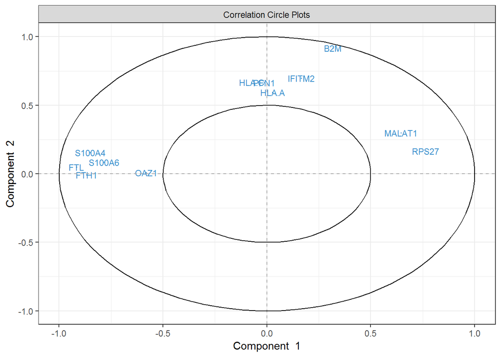

```r
plotVar(modele,comp = 1:2,cex=3)
```

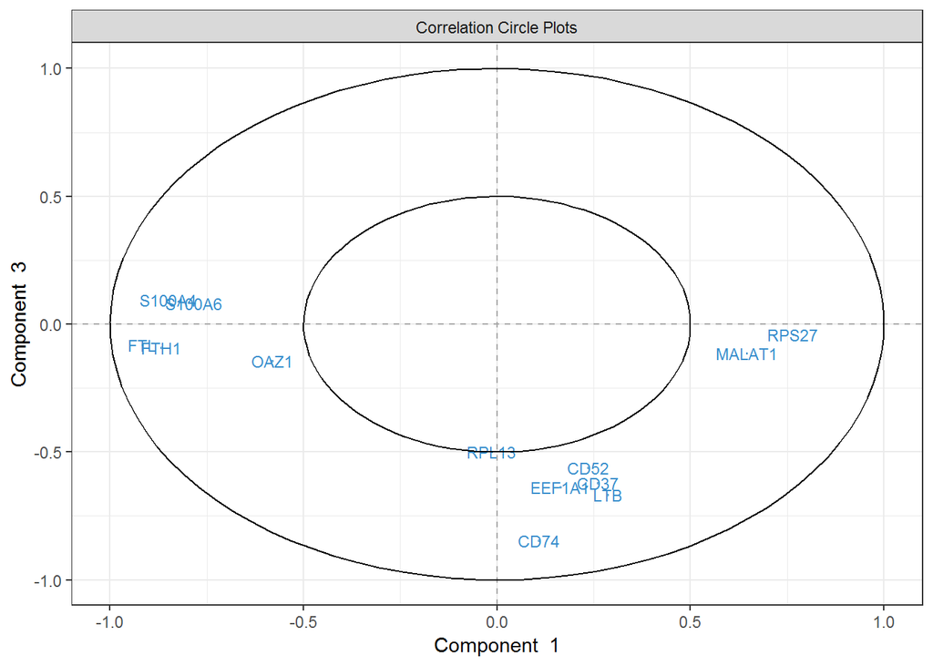

```r
plotVar(modele,comp = c(1,3),cex=3)
```

**What are the problems of that representation ?**

## Contribution plots

Those plots are quite fancy to check the weights of each variable selected along its component. Look for that function in the Help and plot it.

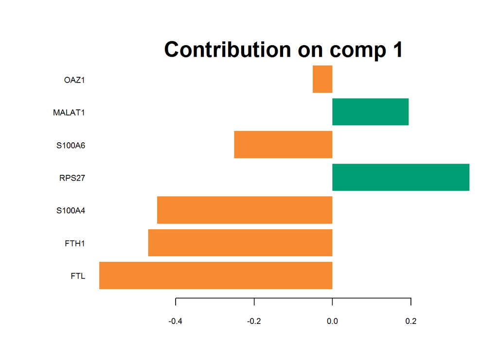

```r
plotLoadings(modele, comp = 1, method = 'mean', contrib = 'max',legend=F)
```

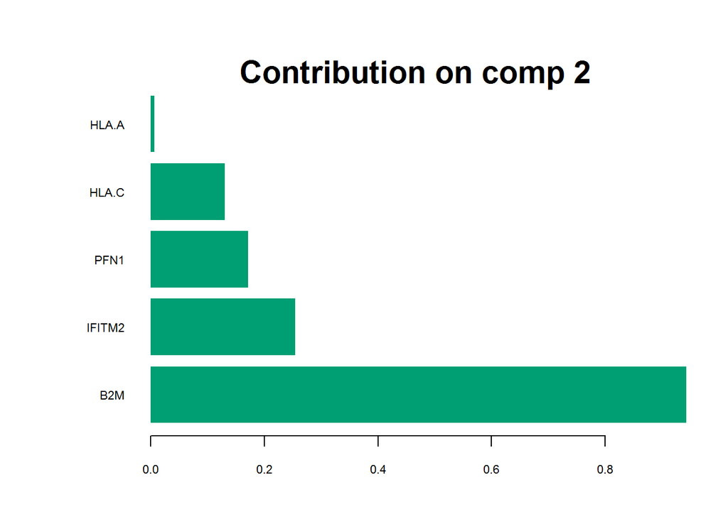

```r
plotLoadings(modele, comp = 2, method = 'mean', contrib = 'max',legend=F)
```

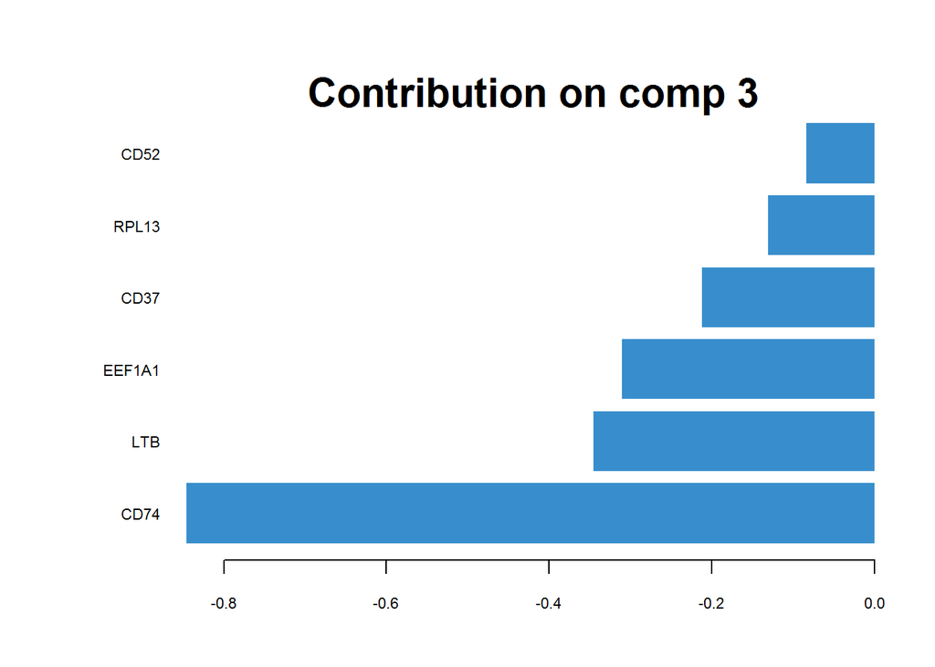

```r
plotLoadings(modele, comp = 3, method = 'mean', contrib = 'max',legend=F)
```

## **cim** representation

An interpretable way of representing the selected genes is to use **cim** representation from mixOmics. Plot the selected genes and only them ;).

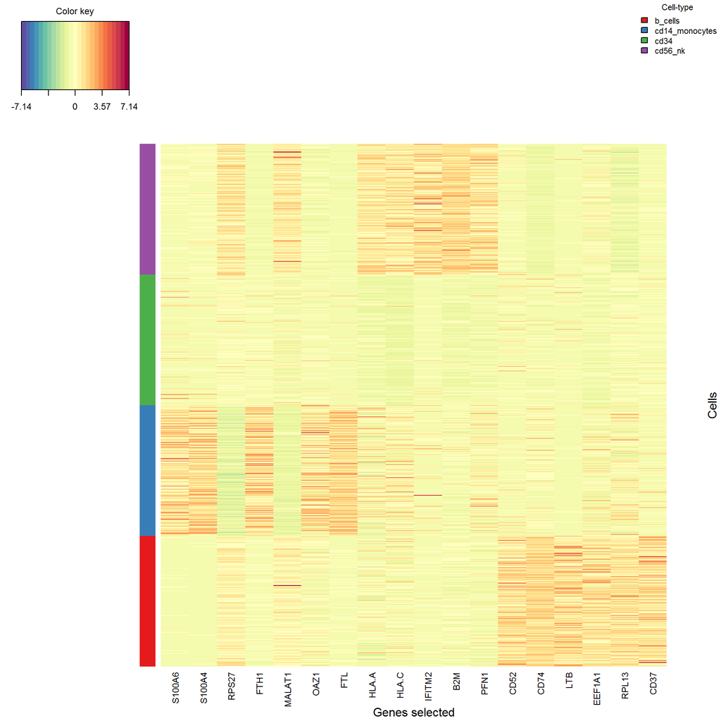

```r
matGenes <- modele$loadings$X[-which(rowSums(modele$loadings$X)==0),]
modele_cim <- plsda(X_4_pop[,
                            which(rowSums(abs(modele$loadings$X))!=0)[
                              order(apply(matGenes,1,function(a){which(a!=0)}))]],
                    y_4_pop,ncomp = 3)
cim(modele_cim,row.names = NA,
    row.sideColors = brewer.pal(4,name = "Set1")[y_4_pop],
    cluster = "none",
    xlab = "Genes selected",ylab = "Cells",
    legend=list( legend = levels(y_4_pop),
    col = brewer.pal(4,name = "Set1"),title = "Cell-type", cex = 0.7),mapping="XY")
```

**How can you comment that figure ?**

**Can you find information redundant with previous figures ?**

## Variances explained

Plot the variance explained by each axis

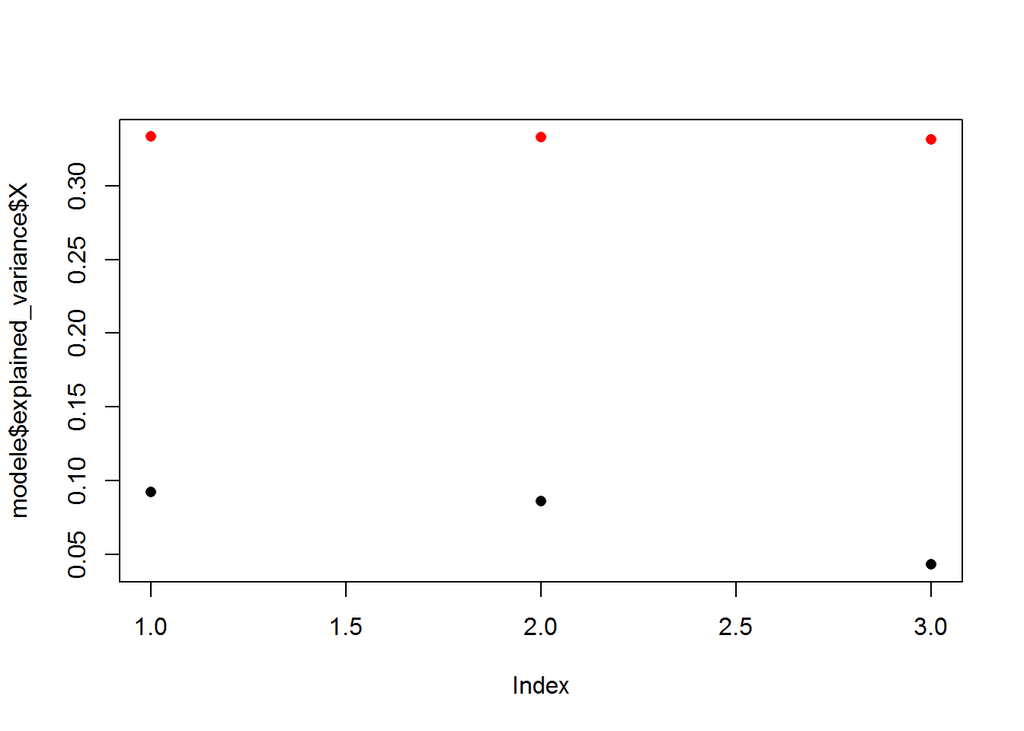

```r
plot(modele$explained_variance$X,ylim=range(c(modele$explained_variance$X,modele$explained_variance$Y)),pch=16)
points(modele$explained_variance$Y,pch=16,col="red")
```

**Are the variances increasing or decreasing ?**

**Is that necessarly the case**

# Predict functions

**PLS**-based methods permit to construct a classification model.

For example, if we want to test a few predictions :

```r
id_test <- c(1,2,5,6,5,22,20,12,55,256,758,726,540,265,799)
predicted_classes <- predict(object = modele,newdata = X_4_pop[id_test,] )
# compare prediction to reality
kable(table(predicted_classes$class$max.dist[,ncomp], y_4_pop[id_test]))
```

|  | b_cells | cd14_monocytes | cd34 | cd56_nk |
| --- | --- | --- | --- | --- |
| b_cells | 9 | 0 | 0 | 0 |
| cd14_monocytes | 0 | 2 | 0 | 0 |
| cd34 | 0 | 0 | 1 | 0 |
| cd56_nk | 0 | 0 | 0 | 3 |

# Do the same with the all dataset

**No cheat here but ask for help if needed!**

# References

Lê Cao, Kim-Anh, Simon Boitard, and Philippe Besse. 2011. “Sparse Pls Discriminant Analysis: Biologically Relevant Feature Selection and Graphical Displays for Multiclass Problems.” *BMC Bioinformatics* 12 (1). BioMed Central: 253.

Zheng, Grace XY, Jessica M Terry, Phillip Belgrader, Paul Ryvkin, Zachary W Bent, Ryan Wilson, Solongo B Ziraldo, et al. 2017. “Massively Parallel Digital Transcriptional Profiling of Single Cells.” *Nature Communications* 8. Nature Publishing Group: 14049.